# **Importing libraries**

```python
import pandas as pd
import seaborn as sb
import matplotlib.pyplot as plt
from warnings import filterwarnings
filterwarnings("ignore")
import numpy as np
from google.colab import drive
from google.colab import files
drive.mount("/content/drive")
```

# **Reading Data**

```python
a1=pd.read_excel("/content/drive/MyDrive/Colab Notebooks/Etlhive/Attrition Project/Attrition Case Study.xlsx")
```

```python
pd.set_option("display.max_columns",100)
```

```python
a1.head(3)
```

|  | Attrition | Age | BusinessTravel | DailyRate | Department | DistanceFromHome | Education | EducationField | EmployeeCount | EmployeeNumber | EnvironmentSatisfaction | Gender | HourlyRate | JobInvolvement | JobLevel | JobRole | JobSatisfaction | MaritalStatus | MonthlyIncome | MonthlyRate | NumCompaniesWorked | Over18 | OverTime | PercentSalaryHike | PerformanceRating | RelationshipSatisfaction | StandardHours | StockOptionLevel | TotalWorkingYears | … |
| --- | --- | --- | --- | --- | --- | --- | --- | --- | --- | --- | --- | --- | --- | --- | --- | --- | --- | --- | --- | --- | --- | --- | --- | --- | --- | --- | --- | --- | --- | --- |
| 0 | 1 | 41 | Travel_Rarely | 1102 | Sales | 1 | 2 | Life Sciences | 1 | 1 | 2 | Female | 94 | 3 | 2 | Sales Executive | 4 | Single | 5993 | 19479 | 8 | Y | Yes | 11 | 3 | 1 | 80 | 0 | 8 | … |
| 1 | 0 | 49 | Travel_Frequently | 279 | Research & Development | 8 | 1 | Life Sciences | 1 | 2 | 3 | Male | 61 | 2 | 2 | Research Scientist | 2 | Married | 5130 | 24907 | 1 | Y | No | 23 | 4 | 4 | 80 | 1 | 10 | … |
| 2 | 1 | 37 | Travel_Rarely | 1373 | Research & Development | 2 | 2 | Other | 1 | 4 | 4 | Male | 92 | 2 | 1 | Laboratory Technician | 3 | Single | 2090 | 2396 | 6 | Y | Yes | 15 | 3 | 2 | 80 | 0 | 7 | … |

# **Uploading Module File**

```python
files.upload()
```

Upload widget is only available when the cell has been executed in the current browser session. Please rerun this cell to enable.

```
Saving practicefunc.py to practicefunc.py
```

[output not shown]

```python
import practicefunc as pf
```

# **Missing Data Treatment**

```python
pf.replacer(a1)
```

```
Attrition                   0
Age                         0
BusinessTravel              0
DailyRate                   0
Department                  0
DistanceFromHome            0
Education                   0
EducationField              0
EmployeeCount               0
EmployeeNumber              0
EnvironmentSatisfaction     0
Gender                      0
HourlyRate                  0
JobInvolvement              0
JobLevel                    0
JobRole                     0
JobSatisfaction             0
MaritalStatus               0
MonthlyIncome               0
MonthlyRate                 0
NumCompaniesWorked          0
Over18                      0
OverTime                    0
PercentSalaryHike           0
PerformanceRating           0
RelationshipSatisfaction    0
StandardHours               0
StockOptionLevel            0
TotalWorkingYears           0
TrainingTimesLastYear       0
WorkLifeBalance             0
YearsAtCompany              0
YearsInCurrentRole          0
YearsSinceLastPromotion     0
YearsWithCurrManager        0
dtype: int64
```

```python
a1.info()
```

```
<class 'pandas.core.frame.DataFrame'>
RangeIndex: 1470 entries, 0 to 1469
Data columns (total 35 columns):
 #   Column                    Non-Null Count  Dtype
---  ------                    --------------  -----
 0   Attrition                 1470 non-null   int64
 1   Age                       1470 non-null   int64
 2   BusinessTravel            1470 non-null   object
 3   DailyRate                 1470 non-null   int64
 4   Department                1470 non-null   object
 5   DistanceFromHome          1470 non-null   int64
 6   Education                 1470 non-null   int64
 7   EducationField            1470 non-null   object
 8   EmployeeCount             1470 non-null   int64
 9   EmployeeNumber            1470 non-null   int64
```

[output cut: 27 more lines]

# **Outlier Analysis**

```python
a=pf.outliers_rem(a1)
```

```
___________________________________________
Features with Outliers:  ['YearsInCurrentRole', 'YearsWithCurrManager', 'TotalWorkingYears', 'YearsAtCompany', 'YearsSinceLastPromotion']
___________________________________________
```

```python
a
```

|  | Attrition | Age | DailyRate | DistanceFromHome | Education | EmployeeCount | EmployeeNumber | EnvironmentSatisfaction | HourlyRate | JobInvolvement | JobLevel | JobSatisfaction | MonthlyIncome | MonthlyRate | NumCompaniesWorked | PercentSalaryHike | PerformanceRating | RelationshipSatisfaction | StandardHours | StockOptionLevel | TotalWorkingYears | TrainingTimesLastYear | WorkLifeBalance | YearsAtCompany | YearsInCurrentRole | YearsSinceLastPromotion | YearsWithCurrManager | BusinessTravel | Department | … |
| --- | --- | --- | --- | --- | --- | --- | --- | --- | --- | --- | --- | --- | --- | --- | --- | --- | --- | --- | --- | --- | --- | --- | --- | --- | --- | --- | --- | --- | --- | --- |
| 0 | 1.0 | 41.0 | 1102.0 | 1.0 | 2.0 | 1.0 | 1.0 | 2.0 | 94.0 | 3.0 | 2.0 | 4.0 | 5993.0 | 19479.0 | 8.0 | 11.0 | 3.0 | 1.0 | 80.0 | 0.0 | 8.0 | 0.0 | 1.0 | 6.0 | 4.0 | 0.0 | 5.0 | Travel_Rarely | Sales | … |
| 1 | 0.0 | 49.0 | 279.0 | 8.0 | 1.0 | 1.0 | 2.0 | 3.0 | 61.0 | 2.0 | 2.0 | 2.0 | 5130.0 | 24907.0 | 1.0 | 23.0 | 4.0 | 4.0 | 80.0 | 1.0 | 10.0 | 3.0 | 3.0 | 10.0 | 7.0 | 1.0 | 7.0 | Travel_Frequently | Research & Development | … |
| 2 | 1.0 | 37.0 | 1373.0 | 2.0 | 2.0 | 1.0 | 4.0 | 4.0 | 92.0 | 2.0 | 1.0 | 3.0 | 2090.0 | 2396.0 | 6.0 | 15.0 | 3.0 | 2.0 | 80.0 | 0.0 | 7.0 | 3.0 | 3.0 | 0.0 | 0.0 | 0.0 | 0.0 | Travel_Rarely | Research & Development | … |
| 3 | 0.0 | 33.0 | 1392.0 | 3.0 | 4.0 | 1.0 | 5.0 | 4.0 | 56.0 | 3.0 | 1.0 | 3.0 | 2909.0 | 23159.0 | 1.0 | 11.0 | 3.0 | 3.0 | 80.0 | 0.0 | 8.0 | 3.0 | 3.0 | 8.0 | 7.0 | 3.0 | 0.0 | Travel_Frequently | Research & Development | … |
| 4 | 0.0 | 27.0 | 591.0 | 2.0 | 1.0 | 1.0 | 7.0 | 1.0 | 40.0 | 3.0 | 1.0 | 2.0 | 3468.0 | 16632.0 | 9.0 | 12.0 | 3.0 | 4.0 | 80.0 | 1.0 | 6.0 | 3.0 | 3.0 | 2.0 | 2.0 | 2.0 | 2.0 | Travel_Rarely | Research & Development | … |
| ... | ... | ... | ... | ... | ... | ... | ... | ... | ... | ... | ... | ... | ... | ... | ... | ... | ... | ... | ... | ... | ... | ... | ... | ... | ... | ... | ... | ... | ... | … |
| 1382 | 0.0 | 36.0 | 884.0 | 23.0 | 2.0 | 1.0 | 2061.0 | 3.0 | 41.0 | 4.0 | 2.0 | 4.0 | 2571.0 | 12290.0 | 4.0 | 17.0 | 3.0 | 3.0 | 80.0 | 1.0 | 17.0 | 3.0 | 3.0 | 5.0 | 2.0 | 0.0 | 3.0 | Non-Travel | Research & Development | … |
| 1383 | 0.0 | 39.0 | 613.0 | 6.0 | 1.0 | 1.0 | 2062.0 | 4.0 | 42.0 | 2.0 | 3.0 | 1.0 | 9991.0 | 21457.0 | 4.0 | 15.0 | 3.0 | 1.0 | 80.0 | 1.0 | 9.0 | 5.0 | 3.0 | 7.0 | 7.0 | 1.0 | 7.0 | Non-Travel | Research & Development | … |
| 1384 | 0.0 | 27.0 | 155.0 | 4.0 | 3.0 | 1.0 | 2064.0 | 2.0 | 87.0 | 4.0 | 2.0 | 2.0 | 6142.0 | 5174.0 | 1.0 | 20.0 | 4.0 | 2.0 | 80.0 | 1.0 | 6.0 | 0.0 | 3.0 | 6.0 | 2.0 | 0.0 | 3.0 | Travel_Rarely | Sales | … |
| 1385 | 0.0 | 49.0 | 1023.0 | 2.0 | 3.0 | 1.0 | 2065.0 | 4.0 | 63.0 | 2.0 | 2.0 | 2.0 | 5390.0 | 13243.0 | 2.0 | 14.0 | 3.0 | 4.0 | 80.0 | 0.0 | 17.0 | 3.0 | 2.0 | 9.0 | 6.0 | 0.0 | 8.0 | Travel_Rarely | Sales | … |
| 1386 | 0.0 | 34.0 | 628.0 | 8.0 | 3.0 | 1.0 | 2068.0 | 2.0 | 82.0 | 4.0 | 2.0 | 3.0 | 4404.0 | 10228.0 | 2.0 | 12.0 | 3.0 | 1.0 | 80.0 | 0.0 | 6.0 | 3.0 | 4.0 | 4.0 | 3.0 | 1.0 | 2.0 | Travel_Rarely | Research & Development | … |

1387 rows × 35 columns

# **Univariate Analysis**

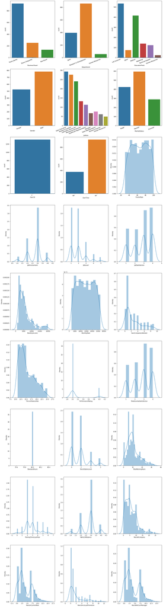

```python
pf.UNI(a)
```

# **Bivariate Analysis**

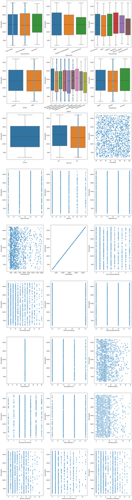

```python
pf.BIV_H(a,"MonthlyRate")
```

# **HeatMap**

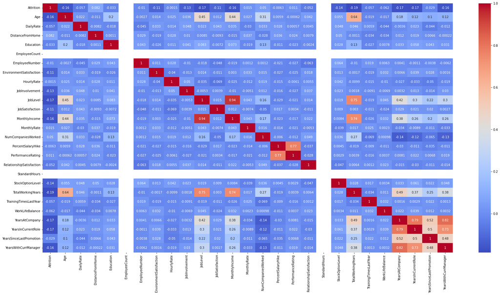

```python
pf.HM(a,(30,15))
```

# **Correlation**

```python
a.corr()[["MonthlyRate"]].sort_values(by="MonthlyRate")
```

|  | MonthlyRate |
| --- | --- |
| StockOptionLevel | -0.038998 |
| YearsAtCompany | -0.033970 |
| YearsWithCurrManager | -0.033466 |
| DailyRate | -0.029844 |
| PerformanceRating | -0.020675 |
| Education | -0.018540 |
| PercentSalaryHike | -0.013630 |
| HourlyRate | -0.011663 |
| YearsSinceLastPromotion | -0.010779 |
| YearsInCurrentRole | -0.008861 |
| JobSatisfaction | -0.007395 |
| RelationshipSatisfaction | -0.005290 |
| JobInvolvement | -0.005142 |
| EmployeeNumber | 0.001158 |
| WorkLifeBalance | 0.002295 |
| Attrition | 0.014888 |
| NumCompaniesWorked | 0.016440 |
| TotalWorkingYears | 0.017482 |
| TrainingTimesLastYear | 0.024648 |
| Age | 0.026954 |
| EnvironmentSatisfaction | 0.032916 |
| DistanceFromHome | 0.037052 |
| MonthlyIncome | 0.042510 |
| JobLevel | 0.043085 |
| MonthlyRate | 1.000000 |
| EmployeeCount | NaN |
| StandardHours | NaN |

# **Skew Analysis**

```python
a.skew()
```

```
Attrition                   1.805983
Age                         0.472280
DailyRate                  -0.017078
DistanceFromHome            0.954752
Education                  -0.289024
EmployeeCount               0.000000
EmployeeNumber              0.018931
EnvironmentSatisfaction    -0.325285
HourlyRate                 -0.030481
JobInvolvement             -0.501401
JobLevel                    1.126075
JobSatisfaction            -0.345612
MonthlyIncome               1.544770
MonthlyRate                 0.030596
NumCompaniesWorked          1.037715
PercentSalaryHike           0.800592
PerformanceRating           1.931566
RelationshipSatisfaction   -0.295686
StandardHours               0.000000
StockOptionLevel            0.962332
TotalWorkingYears           1.034487
TrainingTimesLastYear       0.577614
WorkLifeBalance            -0.557100
YearsAtCompany              1.248623
YearsInCurrentRole          0.726675
YearsSinceLastPromotion     1.756335
YearsWithCurrManager        0.694506
dtype: float64
```

```
The features with high Skewness are:  ['MonthlyIncome', 'YearsSinceLastPromotion', 'Attrition', 'PerformanceRating']
```

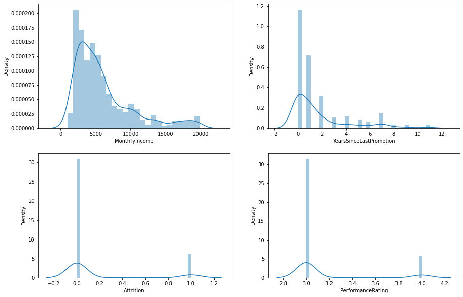

```python
pf.SKEW_plt(a,(15,10))
```

# **Regression (Y = MonthlyRate)**

# **ANOVA**

```python
pf.ANOVA(a,"MonthlyRate")
```

```
[]
```

# **Defining X and Y**

```python
Y=a[["MonthlyRate"]]
```

```python
X=a.drop(labels=["MonthlyRate","EmployeeCount","StandardHours"],axis=1)
```

```python
X.head(2)
```

|  | Attrition | Age | DailyRate | DistanceFromHome | Education | EmployeeNumber | EnvironmentSatisfaction | HourlyRate | JobInvolvement | JobLevel | JobSatisfaction | MonthlyIncome | NumCompaniesWorked | PercentSalaryHike | PerformanceRating | RelationshipSatisfaction | StockOptionLevel | TotalWorkingYears | TrainingTimesLastYear | WorkLifeBalance | YearsAtCompany | YearsInCurrentRole | YearsSinceLastPromotion | YearsWithCurrManager | BusinessTravel | Department | EducationField | Gender | JobRole | … |
| --- | --- | --- | --- | --- | --- | --- | --- | --- | --- | --- | --- | --- | --- | --- | --- | --- | --- | --- | --- | --- | --- | --- | --- | --- | --- | --- | --- | --- | --- | --- |
| 0 | 1.0 | 41.0 | 1102.0 | 1.0 | 2.0 | 1.0 | 2.0 | 94.0 | 3.0 | 2.0 | 4.0 | 5993.0 | 8.0 | 11.0 | 3.0 | 1.0 | 0.0 | 8.0 | 0.0 | 1.0 | 6.0 | 4.0 | 0.0 | 5.0 | Travel_Rarely | Sales | Life Sciences | Female | Sales Executive | … |
| 1 | 0.0 | 49.0 | 279.0 | 8.0 | 1.0 | 2.0 | 3.0 | 61.0 | 2.0 | 2.0 | 2.0 | 5130.0 | 1.0 | 23.0 | 4.0 | 4.0 | 1.0 | 10.0 | 3.0 | 3.0 | 10.0 | 7.0 | 1.0 | 7.0 | Travel_Frequently | Research & Development | Life Sciences | Male | Research Scientist | … |

# **Preprocessing**

```python
Xnew=pf.prep(X)
```

```python
Xnew.head(3)
```

|  | Attrition | Age | DailyRate | DistanceFromHome | Education | EmployeeNumber | EnvironmentSatisfaction | HourlyRate | JobInvolvement | JobLevel | JobSatisfaction | MonthlyIncome | NumCompaniesWorked | PercentSalaryHike | PerformanceRating | RelationshipSatisfaction | StockOptionLevel | TotalWorkingYears | TrainingTimesLastYear | WorkLifeBalance | YearsAtCompany | YearsInCurrentRole | YearsSinceLastPromotion | YearsWithCurrManager | BusinessTravel_Non-Travel | BusinessTravel_Travel_Frequently | BusinessTravel_Travel_Rarely | Department_Human Resources | Department_Research & Development | … |
| --- | --- | --- | --- | --- | --- | --- | --- | --- | --- | --- | --- | --- | --- | --- | --- | --- | --- | --- | --- | --- | --- | --- | --- | --- | --- | --- | --- | --- | --- | --- |
| 0 | 2.248726 | 0.536681 | 0.734325 | -1.011249 | -0.876177 | -1.702014 | -0.665328 | 1.388670 | 0.376231 | 0.043309 | 1.143776 | -0.007750 | 2.125951 | -1.161414 | -0.424765 | -1.575817 | -0.929427 | -0.343728 | -2.171420 | -2.501172 | -0.022350 | 0.040903 | -0.710699 | 0.368270 | 0 | 0 | 1 | 0 | 0 | … |
| 1 | -0.444696 | 1.442111 | -1.307769 | -0.145521 | -1.853858 | -1.700354 | 0.251978 | -0.239091 | -1.034126 | 0.043309 | -0.673426 | -0.210963 | -0.672430 | 2.146916 | 2.354241 | 1.199034 | 0.238250 | -0.045106 | 0.151871 | 0.336558 | 0.832812 | 0.965895 | -0.310480 | 0.982200 | 0 | 1 | 0 | 0 | 1 | … |
| 2 | 2.248726 | 0.083966 | 1.406752 | -0.887573 | -0.876177 | -1.697034 | 1.169285 | 1.290017 | -1.034126 | -0.941432 | 0.235175 | -0.926802 | 1.326414 | -0.058637 | -0.424765 | -0.650866 | -0.929427 | -0.493039 | 0.151871 | 0.336558 | -1.305094 | -1.192419 | -0.710699 | -1.166556 | 0 | 0 | 1 | 0 | 1 | … |

# **OLS Regression Backward Elimination**

### **Model 1**

```python
from sklearn.model_selection import train_test_split
xtrain,xtest,ytrain,ytest=train_test_split(Xnew,Y,test_size=0.2,random_state=31)

from statsmodels.api import OLS,add_constant
xconst=add_constant(xtrain)
ols=OLS(ytrain,xtrain)
model=ols.fit()
print("___________________________________________________")

print("Adjusted Rsquared: ",round(model.rsquared_adj,5))
print("___________________________________________________")
print("___________________________________________________")
```

```
___________________________________________________
Adjusted Rsquared:  0.75305
___________________________________________________
___________________________________________________
```

### **Pvalues**

```python
PVAL=list(model.pvalues.sort_values().index)
PVAL
```

```
['Over18_Y',
 'Gender_Female',
 'Gender_Male',
 'OverTime_Yes',
 'OverTime_No',
 'MaritalStatus_Divorced',
 'BusinessTravel_Travel_Rarely',
 'MaritalStatus_Single',
 'BusinessTravel_Travel_Frequently',
 'MaritalStatus_Married',
 'EducationField_Medical',
 'EducationField_Life Sciences',
 'Department_Human Resources',
 'JobRole_Manager',
 'EducationField_Technical Degree',
 'StockOptionLevel',
 'EducationField_Other',
 'YearsAtCompany',
 'BusinessTravel_Non-Travel',
 'JobRole_Sales Executive',
 'EducationField_Human Resources',
 'JobRole_Sales Representative',
 'EducationField_Marketing',
 'JobRole_Human Resources',
 'Attrition',
 'JobRole_Laboratory Technician',
 'YearsInCurrentRole',
 'RelationshipSatisfaction',
 'DistanceFromHome',
 'JobInvolvement',
 'Department_Sales',
 'Age',
 'TotalWorkingYears',
 'DailyRate',
 'YearsSinceLastPromotion',
 'NumCompaniesWorked',
 'HourlyRate',
 'JobLevel',
 'TrainingTimesLastYear',
 'JobSatisfaction',
 'EnvironmentSatisfaction',
 'EmployeeNumber',
 'PercentSalaryHike',
 'PerformanceRating',
 'MonthlyIncome',
 'JobRole_Manufacturing Director',
 'JobRole_Research Scientist',
 'Department_Research & Development',
 'JobRole_Healthcare Representative',
 'Education',
 'YearsWithCurrManager',
 'WorkLifeBalance',
 'JobRole_Research Director']
```

### **Model 2**

```python
col_to_drop=PVAL[-1]
print("Dropped Column: ",col_to_drop)
PVAL.remove(col_to_drop)

Xnew=Xnew.drop(labels=[col_to_drop],axis=1)
from sklearn.model_selection import train_test_split
xtrain,xtest,ytrain,ytest=train_test_split(Xnew,Y,test_size=0.2,random_state=31)

from statsmodels.api import OLS,add_constant
xconst=add_constant(xtrain)
ols=OLS(ytrain,xtrain)
model=ols.fit()
print("___________________________________________________")

print("Adjusted Rsquared: ",round(model.rsquared_adj,5))
print("___________________________________________________")
print("___________________________________________________")
```

```
Dropped Column:  JobRole_Research Director
___________________________________________________
Adjusted Rsquared:  0.75305
___________________________________________________
___________________________________________________
```

### **Model 3**

```python
col_to_drop=PVAL[-1]
print("Dropped Column: ",col_to_drop)
PVAL.remove(col_to_drop)

Xnew=Xnew.drop(labels=[col_to_drop],axis=1)
from sklearn.model_selection import train_test_split
xtrain,xtest,ytrain,ytest=train_test_split(Xnew,Y,test_size=0.2,random_state=31)

from statsmodels.api import OLS,add_constant
xconst=add_constant(xtrain)
ols=OLS(ytrain,xtrain)
model=ols.fit()
print("___________________________________________________")

print("Adjusted Rsquared: ",round(model.rsquared_adj,5))
print("___________________________________________________")
print("___________________________________________________")
```

```
Dropped Column:  WorkLifeBalance
___________________________________________________
Adjusted Rsquared:  0.75328
___________________________________________________
___________________________________________________
```

### **Model 4**

```python
col_to_drop=PVAL[-1]
print("Dropped Column: ",col_to_drop)
PVAL.remove(col_to_drop)

Xnew=Xnew.drop(labels=[col_to_drop],axis=1)
from sklearn.model_selection import train_test_split
xtrain,xtest,ytrain,ytest=train_test_split(Xnew,Y,test_size=0.2,random_state=31)

from statsmodels.api import OLS,add_constant
xconst=add_constant(xtrain)
ols=OLS(ytrain,xtrain)
model=ols.fit()
print("___________________________________________________")

print("Adjusted Rsquared: ",round(model.rsquared_adj,5))
print("___________________________________________________")
print("___________________________________________________")
```

```
Dropped Column:  YearsWithCurrManager
___________________________________________________
Adjusted Rsquared:  0.75351
___________________________________________________
___________________________________________________
```

### **Model 5**

```python
col_to_drop=PVAL[-1]
print("Dropped Column: ",col_to_drop)
PVAL.remove(col_to_drop)

Xnew=Xnew.drop(labels=[col_to_drop],axis=1)
from sklearn.model_selection import train_test_split
xtrain,xtest,ytrain,ytest=train_test_split(Xnew,Y,test_size=0.2,random_state=31)

from statsmodels.api import OLS,add_constant
xconst=add_constant(xtrain)
ols=OLS(ytrain,xtrain)
model=ols.fit()
print("___________________________________________________")

print("Adjusted Rsquared: ",round(model.rsquared_adj,5))
print("___________________________________________________")
print("___________________________________________________")
```

```
Dropped Column:  Education
___________________________________________________
Adjusted Rsquared:  0.75374
___________________________________________________
___________________________________________________
```

### **Model 6**

```python
col_to_drop=PVAL[-1]
print("Dropped Column: ",col_to_drop)
PVAL.remove(col_to_drop)

Xnew=Xnew.drop(labels=[col_to_drop],axis=1)
from sklearn.model_selection import train_test_split
xtrain,xtest,ytrain,ytest=train_test_split(Xnew,Y,test_size=0.2,random_state=31)

from statsmodels.api import OLS,add_constant
xconst=add_constant(xtrain)
ols=OLS(ytrain,xtrain)
model=ols.fit()
print("___________________________________________________")

print("Adjusted Rsquared: ",round(model.rsquared_adj,5))
print("___________________________________________________")
print("___________________________________________________")
```

```
Dropped Column:  JobRole_Healthcare Representative
___________________________________________________
Adjusted Rsquared:  0.75396
___________________________________________________
___________________________________________________
```

### **Model 7**

```python
col_to_drop=PVAL[-1]
print("Dropped Column: ",col_to_drop)
PVAL.remove(col_to_drop)

Xnew=Xnew.drop(labels=[col_to_drop],axis=1)
from sklearn.model_selection import train_test_split
xtrain,xtest,ytrain,ytest=train_test_split(Xnew,Y,test_size=0.2,random_state=31)

from statsmodels.api import OLS,add_constant
xconst=add_constant(xtrain)
ols=OLS(ytrain,xtrain)
model=ols.fit()
print("___________________________________________________")

print("Adjusted Rsquared: ",round(model.rsquared_adj,5))
print("___________________________________________________")
print("___________________________________________________")
```

```
Dropped Column:  Department_Research & Development
___________________________________________________
Adjusted Rsquared:  0.75396
___________________________________________________
___________________________________________________
```

### **Model 8**

```python
col_to_drop=PVAL[-1]
print("Dropped Column: ",col_to_drop)
PVAL.remove(col_to_drop)

Xnew=Xnew.drop(labels=[col_to_drop],axis=1)
from sklearn.model_selection import train_test_split
xtrain,xtest,ytrain,ytest=train_test_split(Xnew,Y,test_size=0.2,random_state=31)

from statsmodels.api import OLS,add_constant
xconst=add_constant(xtrain)
ols=OLS(ytrain,xtrain)
model=ols.fit()
print("___________________________________________________")

print("Adjusted Rsquared: ",round(model.rsquared_adj,5))
print("___________________________________________________")
print("___________________________________________________")
```

```
Dropped Column:  JobRole_Research Scientist
___________________________________________________
Adjusted Rsquared:  0.75419
___________________________________________________
___________________________________________________
```

### **Model 9**

```python
col_to_drop=PVAL[-1]
print("Dropped Column: ",col_to_drop)
PVAL.remove(col_to_drop)

Xnew=Xnew.drop(labels=[col_to_drop],axis=1)
from sklearn.model_selection import train_test_split
xtrain,xtest,ytrain,ytest=train_test_split(Xnew,Y,test_size=0.2,random_state=31)

from statsmodels.api import OLS,add_constant
xconst=add_constant(xtrain)
ols=OLS(ytrain,xtrain)
model=ols.fit()
print("___________________________________________________")

print("Adjusted Rsquared: ",round(model.rsquared_adj,5))
print("___________________________________________________")
print("___________________________________________________")
```

```
Dropped Column:  JobRole_Manufacturing Director
___________________________________________________
Adjusted Rsquared:  0.75441
___________________________________________________
___________________________________________________
```

### **Model 10**

```python
col_to_drop=PVAL[-1]
print("Dropped Column: ",col_to_drop)
PVAL.remove(col_to_drop)

Xnew=Xnew.drop(labels=[col_to_drop],axis=1)
from sklearn.model_selection import train_test_split
xtrain,xtest,ytrain,ytest=train_test_split(Xnew,Y,test_size=0.2,random_state=31)

from statsmodels.api import OLS,add_constant
xconst=add_constant(xtrain)
ols=OLS(ytrain,xtrain)
model=ols.fit()
print("___________________________________________________")

print("Adjusted Rsquared: ",round(model.rsquared_adj,5))
print("___________________________________________________")
print("___________________________________________________")
```

```
Dropped Column:  MonthlyIncome
___________________________________________________
Adjusted Rsquared:  0.75462
___________________________________________________
___________________________________________________
```

### **Model 11**

```python
col_to_drop=PVAL[-1]
print("Dropped Column: ",col_to_drop)
PVAL.remove(col_to_drop)

Xnew=Xnew.drop(labels=[col_to_drop],axis=1)
from sklearn.model_selection import train_test_split
xtrain,xtest,ytrain,ytest=train_test_split(Xnew,Y,test_size=0.2,random_state=31)

from statsmodels.api import OLS,add_constant
xconst=add_constant(xtrain)
ols=OLS(ytrain,xtrain)
model=ols.fit()
print("___________________________________________________")

print("Adjusted Rsquared: ",round(model.rsquared_adj,5))
print("___________________________________________________")
print("___________________________________________________")
```

```
Dropped Column:  PerformanceRating
___________________________________________________
Adjusted Rsquared:  0.75483
___________________________________________________
___________________________________________________
```

### **Model 12**

```python
col_to_drop=PVAL[-1]
print("Dropped Column: ",col_to_drop)
PVAL.remove(col_to_drop)

Xnew=Xnew.drop(labels=[col_to_drop],axis=1)
from sklearn.model_selection import train_test_split
xtrain,xtest,ytrain,ytest=train_test_split(Xnew,Y,test_size=0.2,random_state=31)

from statsmodels.api import OLS,add_constant
xconst=add_constant(xtrain)
ols=OLS(ytrain,xtrain)
model=ols.fit()
print("___________________________________________________")

print("Adjusted Rsquared: ",round(model.rsquared_adj,5))
print("___________________________________________________")
print("___________________________________________________")
```

```
Dropped Column:  PercentSalaryHike
___________________________________________________
Adjusted Rsquared:  0.75506
___________________________________________________
___________________________________________________
```

### **Model 13**

```python
col_to_drop=PVAL[-1]
print("Dropped Column: ",col_to_drop)
PVAL.remove(col_to_drop)

Xnew=Xnew.drop(labels=[col_to_drop],axis=1)
from sklearn.model_selection import train_test_split
xtrain,xtest,ytrain,ytest=train_test_split(Xnew,Y,test_size=0.2,random_state=31)

from statsmodels.api import OLS,add_constant
xconst=add_constant(xtrain)
ols=OLS(ytrain,xtrain)
model=ols.fit()
print("___________________________________________________")

print("Adjusted Rsquared: ",round(model.rsquared_adj,5))
print("___________________________________________________")
print("___________________________________________________")
```

```
Dropped Column:  EmployeeNumber
___________________________________________________
Adjusted Rsquared:  0.75526
___________________________________________________
___________________________________________________
```

### **Model 14**

```python
col_to_drop=PVAL[-1]
print("Dropped Column: ",col_to_drop)
PVAL.remove(col_to_drop)

Xnew=Xnew.drop(labels=[col_to_drop],axis=1)
from sklearn.model_selection import train_test_split
xtrain,xtest,ytrain,ytest=train_test_split(Xnew,Y,test_size=0.2,random_state=31)

from statsmodels.api import OLS,add_constant
xconst=add_constant(xtrain)
ols=OLS(ytrain,xtrain)
model=ols.fit()
print("___________________________________________________")

print("Adjusted Rsquared: ",round(model.rsquared_adj,5))
print("___________________________________________________")
print("___________________________________________________")
```

```
Dropped Column:  EnvironmentSatisfaction
___________________________________________________
Adjusted Rsquared:  0.75546
___________________________________________________
___________________________________________________
```

### **Model 15**

```python
col_to_drop=PVAL[-1]
print("Dropped Column: ",col_to_drop)
PVAL.remove(col_to_drop)

Xnew=Xnew.drop(labels=[col_to_drop],axis=1)
from sklearn.model_selection import train_test_split
xtrain,xtest,ytrain,ytest=train_test_split(Xnew,Y,test_size=0.2,random_state=31)

from statsmodels.api import OLS,add_constant
xconst=add_constant(xtrain)
ols=OLS(ytrain,xtrain)
model=ols.fit()
print("___________________________________________________")

print("Adjusted Rsquared: ",round(model.rsquared_adj,5))
print("___________________________________________________")
print("___________________________________________________")
```

```
Dropped Column:  JobSatisfaction
___________________________________________________
Adjusted Rsquared:  0.75563
___________________________________________________
___________________________________________________
```

### **Best Model**

```python
col_to_drop=PVAL[-1]
print("Dropped Column: ",col_to_drop)
PVAL.remove(col_to_drop)

Xnew=Xnew.drop(labels=[col_to_drop],axis=1)
from sklearn.model_selection import train_test_split
xtrain,xtest,ytrain,ytest=train_test_split(Xnew,Y,test_size=0.2,random_state=31)

from statsmodels.api import OLS,add_constant
xconst=add_constant(xtrain)
ols=OLS(ytrain,xtrain)
model=ols.fit()
print("___________________________________________________")

print("Adjusted Rsquared: ",round(model.rsquared_adj,5))
print("___________________________________________________")
print("___________________________________________________")
```

```
Dropped Column:  TrainingTimesLastYear
___________________________________________________
Adjusted Rsquared:  0.75581
___________________________________________________
___________________________________________________
```

```python
Xnew.head(3)
```

|  | Attrition | Age | DailyRate | DistanceFromHome | HourlyRate | JobInvolvement | JobLevel | NumCompaniesWorked | RelationshipSatisfaction | StockOptionLevel | TotalWorkingYears | YearsAtCompany | YearsInCurrentRole | YearsSinceLastPromotion | BusinessTravel_Non-Travel | BusinessTravel_Travel_Frequently | BusinessTravel_Travel_Rarely | Department_Human Resources | Department_Sales | EducationField_Human Resources | EducationField_Life Sciences | EducationField_Marketing | EducationField_Medical | EducationField_Other | EducationField_Technical Degree | Gender_Female | Gender_Male | JobRole_Human Resources | JobRole_Laboratory Technician | … |
| --- | --- | --- | --- | --- | --- | --- | --- | --- | --- | --- | --- | --- | --- | --- | --- | --- | --- | --- | --- | --- | --- | --- | --- | --- | --- | --- | --- | --- | --- | --- |
| 0 | 2.248726 | 0.536681 | 0.734325 | -1.011249 | 1.388670 | 0.376231 | 0.043309 | 2.125951 | -1.575817 | -0.929427 | -0.343728 | -0.022350 | 0.040903 | -0.710699 | 0 | 0 | 1 | 0 | 1 | 0 | 1 | 0 | 0 | 0 | 0 | 1 | 0 | 0 | 0 | … |
| 1 | -0.444696 | 1.442111 | -1.307769 | -0.145521 | -0.239091 | -1.034126 | 0.043309 | -0.672430 | 1.199034 | 0.238250 | -0.045106 | 0.832812 | 0.965895 | -0.310480 | 0 | 1 | 0 | 0 | 0 | 0 | 1 | 0 | 0 | 0 | 0 | 0 | 1 | 0 | 0 | … |
| 2 | 2.248726 | 0.083966 | 1.406752 | -0.887573 | 1.290017 | -1.034126 | -0.941432 | 1.326414 | -0.650866 | -0.929427 | -0.493039 | -1.305094 | -1.192419 | -0.710699 | 0 | 0 | 1 | 0 | 0 | 0 | 0 | 0 | 0 | 1 | 0 | 0 | 1 | 0 | 1 | … |

# **Check for Bias and Variance**

```python
from sklearn.model_selection import train_test_split
xtrain,xtest,ytrain,ytest=train_test_split(Xnew,Y,test_size=0.2,random_state=31)

from sklearn.linear_model import LinearRegression
lm=LinearRegression()
model=lm.fit(xtrain,ytrain)
bias=model.predict(xtrain)
variance=model.predict(xtest)
from sklearn.metrics import mean_absolute_error
tr_err=mean_absolute_error(ytrain,bias)
ts_err=mean_absolute_error(ytest,variance)
print("____________________________________________")
print("Training Error: ",round(tr_err,4))
print("Testing Error: ",round(ts_err,4))
print("____________________________________________")
```

```
____________________________________________
Training Error:  5929.0956
Testing Error:  6654.7214
____________________________________________
```

# **Regularisation Using Ridge**

```python
vals_to_try=[]
x=1
for i in range(0,50):
  x=x-0.001
  vals_to_try.append(round(x,3))
x=1
for i in range(0,50):
  x=x+0.001
  vals_to_try.append(round(x,3))

tg={"alpha":vals_to_try}

from sklearn.linear_model import Ridge
rr=Ridge()
from sklearn.model_selection import GridSearchCV
cv=GridSearchCV(rr,tg,scoring="neg_mean_absolute_error",cv=4)
cvmodel=cv.fit(xtrain,ytrain)
cvmodel.best_params_
```

```
{'alpha': 1.05}
```

```python
rr=Ridge(alpha=1.05)
model=rr.fit(xtrain,ytrain)
bias1=model.predict(xtrain)
variance1=model.predict(xtest)
from sklearn.metrics import mean_absolute_error
tr_err1=mean_absolute_error(ytrain,bias1)
ts_err1=mean_absolute_error(ytest,variance1)
print("____________________________________________")
print("Training Error: ",round(tr_err1,4))
print("Testing Error: ",round(ts_err1,4))
print("____________________________________________")
```

```
____________________________________________
Training Error:  5929.4544
Testing Error:  6621.4571
____________________________________________
```

# **Regularisation Using Lasso**

```python
vals_to_try=[]
x=1
for i in range(0,50):
  x=x-0.001
  vals_to_try.append(round(x,3))
x=1
for i in range(0,50):
  x=x+0.001
  vals_to_try.append(round(x,3))

tg={"alpha":vals_to_try}

from sklearn.linear_model import Lasso
ls=Lasso()
from sklearn.model_selection import GridSearchCV
cv=GridSearchCV(ls,tg,scoring="neg_mean_absolute_error",cv=4)
cvmodel=cv.fit(xtrain,ytrain)
cvmodel.best_params_
```

```
{'alpha': 0.95}
```

```python
ls=Lasso(alpha=0.95)
model=ls.fit(xtrain,ytrain)
bias2=model.predict(xtrain)
variance2=model.predict(xtest)
from sklearn.metrics import mean_absolute_error
tr_err2=mean_absolute_error(ytrain,bias2)
ts_err2=mean_absolute_error(ytest,variance2)
print("____________________________________________")
print("Training Error: ",round(tr_err2,4))
print("Testing Error: ",round(ts_err2,4))
print("____________________________________________")
```

```
____________________________________________
Training Error:  5928.6517
Testing Error:  6644.8848
____________________________________________
```

# **KNN Regression**

```python
a.head()
```

|  | Attrition | Age | DailyRate | DistanceFromHome | Education | EmployeeCount | EmployeeNumber | EnvironmentSatisfaction | HourlyRate | JobInvolvement | JobLevel | JobSatisfaction | MonthlyIncome | MonthlyRate | NumCompaniesWorked | PercentSalaryHike | PerformanceRating | RelationshipSatisfaction | StandardHours | StockOptionLevel | TotalWorkingYears | TrainingTimesLastYear | WorkLifeBalance | YearsAtCompany | YearsInCurrentRole | YearsSinceLastPromotion | YearsWithCurrManager | BusinessTravel | Department | … |
| --- | --- | --- | --- | --- | --- | --- | --- | --- | --- | --- | --- | --- | --- | --- | --- | --- | --- | --- | --- | --- | --- | --- | --- | --- | --- | --- | --- | --- | --- | --- |
| 0 | 1.0 | 41.0 | 1102.0 | 1.0 | 2.0 | 1.0 | 1.0 | 2.0 | 94.0 | 3.0 | 2.0 | 4.0 | 5993.0 | 19479.0 | 8.0 | 11.0 | 3.0 | 1.0 | 80.0 | 0.0 | 8.0 | 0.0 | 1.0 | 6.0 | 4.0 | 0.0 | 5.0 | Travel_Rarely | Sales | … |
| 1 | 0.0 | 49.0 | 279.0 | 8.0 | 1.0 | 1.0 | 2.0 | 3.0 | 61.0 | 2.0 | 2.0 | 2.0 | 5130.0 | 24907.0 | 1.0 | 23.0 | 4.0 | 4.0 | 80.0 | 1.0 | 10.0 | 3.0 | 3.0 | 10.0 | 7.0 | 1.0 | 7.0 | Travel_Frequently | Research & Development | … |
| 2 | 1.0 | 37.0 | 1373.0 | 2.0 | 2.0 | 1.0 | 4.0 | 4.0 | 92.0 | 2.0 | 1.0 | 3.0 | 2090.0 | 2396.0 | 6.0 | 15.0 | 3.0 | 2.0 | 80.0 | 0.0 | 7.0 | 3.0 | 3.0 | 0.0 | 0.0 | 0.0 | 0.0 | Travel_Rarely | Research & Development | … |
| 3 | 0.0 | 33.0 | 1392.0 | 3.0 | 4.0 | 1.0 | 5.0 | 4.0 | 56.0 | 3.0 | 1.0 | 3.0 | 2909.0 | 23159.0 | 1.0 | 11.0 | 3.0 | 3.0 | 80.0 | 0.0 | 8.0 | 3.0 | 3.0 | 8.0 | 7.0 | 3.0 | 0.0 | Travel_Frequently | Research & Development | … |
| 4 | 0.0 | 27.0 | 591.0 | 2.0 | 1.0 | 1.0 | 7.0 | 1.0 | 40.0 | 3.0 | 1.0 | 2.0 | 3468.0 | 16632.0 | 9.0 | 12.0 | 3.0 | 4.0 | 80.0 | 1.0 | 6.0 | 3.0 | 3.0 | 2.0 | 2.0 | 2.0 | 2.0 | Travel_Rarely | Research & Development | … |

## **Preprocessing**

```python
#Preprocessing

Xknn=pf.prep(X)
```

## **KNN Regressor Model**

```python
from sklearn.model_selection import train_test_split
xtrain,xtest,ytrain,ytest=train_test_split(Xknn,Y,test_size=0.2,random_state=31)

from sklearn.neighbors import KNeighborsRegressor
knr=KNeighborsRegressor(n_neighbors=5)
model_knr=knr.fit(xtrain,ytrain)
KNRbias=model_knr.predict(xtrain)
KNRvariance=model_knr.predict(xtest)

from sklearn.metrics import mean_absolute_error
tr_err_KNR=mean_absolute_error(ytrain,KNRbias)
ts_err_KNR=mean_absolute_error(ytest,KNRvariance)

print("____________________________________________")
print("Training Error: ",round(tr_err_KNR,4))
print("Testing Error: ",round(ts_err_KNR,4))
print("____________________________________________")
```

```
____________________________________________
Training Error:  5336.978
Testing Error:  6618.6748
____________________________________________
```

## **Finding value of best n_neighbors**

```python
from sklearn.model_selection import GridSearchCV
tg={"n_neighbors":range(2,15)}
knr=KNeighborsRegressor()
cv=GridSearchCV(knr,tg,scoring="neg_mean_absolute_error",cv=4)
cvmodel=cv.fit(Xknn,Y)
cvmodel.best_params_
```

```
{'n_neighbors': 14}
```

```python
from sklearn.model_selection import train_test_split
xtrain,xtest,ytrain,ytest=train_test_split(Xknn,Y,test_size=0.2,random_state=31)

from sklearn.neighbors import KNeighborsRegressor
knr=KNeighborsRegressor(n_neighbors=14)
model_knr=knr.fit(xtrain,ytrain)
KNRbias=model_knr.predict(xtrain)
KNRvariance=model_knr.predict(xtest)

from sklearn.metrics import mean_absolute_error
tr_err_KNR=mean_absolute_error(ytrain,KNRbias)
ts_err_KNR=mean_absolute_error(ytest,KNRvariance)

print("____________________________________________")
print("Training Error KNN: ",round(tr_err_KNR,4))
print("Testing Error KNN: ",round(ts_err_KNR,4))
print("____________________________________________")
```

```
____________________________________________
Training Error KNN:  5774.0829
Testing Error KNN:  6576.1716
____________________________________________
```

# **Decision Tree Regressor**

```python
Xdt=pf.prep(X)
```

```python
from sklearn.model_selection import train_test_split
xtrain,xtest,ytrain,ytest=train_test_split(Xdt,Y,test_size=0.2,random_state=31)

from sklearn.tree import DecisionTreeRegressor
dtr=DecisionTreeRegressor(random_state=21)
model_dtr=dtr.fit(xtrain,ytrain)

pred_tr_DTR = model_dtr.predict(xtrain)
pred_ts_DTR = model_dtr.predict(xtest)

from sklearn.metrics import mean_absolute_error
tr_err_DTR = mean_absolute_error(ytrain,pred_tr_DTR)
ts_err_DTR = mean_absolute_error(ytest,pred_ts_DTR)
print("____________________________________________")
print("Training Error DTR: ",round(tr_err_DTR,4))
print("Testing Error DTR: ",round(ts_err_DTR,4))
print("____________________________________________")
```

```
____________________________________________
Training Error DTR:  0.0
Testing Error DTR:  8277.8345
____________________________________________
```

## **Reduce overfitting by:**

**PRUNING**

1. max_depth
2. min_samples_leaf
3. min_samples_split

```python
from sklearn.model_selection import GridSearchCV

tg = {"max_depth":range(1,20)}
dtr = DecisionTreeRegressor(random_state=21,max_depth=3)

cv = GridSearchCV(dtr,tg,scoring="neg_mean_absolute_error",cv=4)
cvmodel = cv.fit(xtrain,ytrain)
cvmodel.best_params_
```

```
{'max_depth': 1}
```

```python
from sklearn.model_selection import GridSearchCV

tg = {"min_samples_leaf":range(1,20)}
dtr = DecisionTreeRegressor(random_state=21,min_samples_leaf=10)

cv = GridSearchCV(dtr,tg,scoring="neg_mean_absolute_error",cv=4)
cvmodel = cv.fit(xtrain,ytrain)
cvmodel.best_params_
```

```
{'min_samples_leaf': 19}
```

```python
from sklearn.model_selection import GridSearchCV

tg = {"min_samples_split":range(1,20)}
dtr = DecisionTreeRegressor(random_state=21,min_samples_split=10)

cv = GridSearchCV(dtr,tg,scoring="neg_mean_absolute_error",cv=4)
cvmodel = cv.fit(xtrain,ytrain)
cvmodel.best_params_
```

```
{'min_samples_split': 19}
```

```python
from sklearn.tree import DecisionTreeRegressor
dtr=DecisionTreeRegressor(random_state=21,max_depth=1)
model_dtr_md=dtr.fit(xtrain,ytrain)

pred_tr_DTR_md = model_dtr_md.predict(xtrain)
pred_ts_DTR_md = model_dtr_md.predict(xtest)

from sklearn.metrics import mean_absolute_error
tr_err_DTR_md = mean_absolute_error(ytrain,pred_tr_DTR_md)
ts_err_DTR_md = mean_absolute_error(ytest,pred_ts_DTR_md)
print("____________________________________________")
print("Training Error DTR max_depth: ",round(tr_err_DTR_md,4))
print("Testing Error DTR max_depth: ",round(ts_err_DTR_md,4))
print("____________________________________________")
```

```
____________________________________________
Training Error DTR max_depth:  5995.4397
Testing Error DTR max_depth:  6377.7184
____________________________________________
```

```python
from sklearn.tree import DecisionTreeRegressor
dtr=DecisionTreeRegressor(random_state=21,min_samples_leaf=19)
model_mleaf=dtr.fit(xtrain,ytrain)

pred_tr_DTR_mleaf = model_mleaf.predict(xtrain)
pred_ts_DTR_mleaf = model_mleaf.predict(xtest)

from sklearn.metrics import mean_absolute_error
tr_err_DTR_mleaf = mean_absolute_error(ytrain,pred_tr_DTR_mleaf)
ts_err_DTR_mleaf = mean_absolute_error(ytest,pred_ts_DTR_mleaf)
print("____________________________________________")
print("Training Error DTR min_samples_leaf: ",round(tr_err_DTR_mleaf,4))
print("Testing Error DTR min_samples_leaf: ",round(ts_err_DTR_mleaf,4))
print("____________________________________________")
```

```
____________________________________________
Training Error DTR min_samples_leaf:  5113.3343
Testing Error DTR min_samples_leaf:  6886.2578
____________________________________________
```

```python
from sklearn.tree import DecisionTreeRegressor
dtr=DecisionTreeRegressor(random_state=21,min_samples_split=19)
model_msplit=dtr.fit(xtrain,ytrain)

pred_tr_DTR_msplit = model_msplit.predict(xtrain)
pred_ts_DTR_msplit = model_msplit.predict(xtest)

from sklearn.metrics import mean_absolute_error
tr_err_DTR_msplit = mean_absolute_error(ytrain,pred_tr_DTR_msplit)
ts_err_DTR_msplit = mean_absolute_error(ytest,pred_ts_DTR_msplit)
print("____________________________________________")
print("Training Error DTR min_samples_split: ",round(tr_err_DTR_msplit,4))
print("Testing Error DTR min_samples_split: ",round(ts_err_DTR_msplit,4))
print("____________________________________________")
```

```
____________________________________________
Training Error DTR min_samples_split:  3553.0846
Testing Error DTR min_samples_split:  7569.7757
____________________________________________
```

# **Decision Tree AdaBoost**

```python
from sklearn.ensemble import AdaBoostRegressor
dtr = DecisionTreeRegressor(random_state=21,min_samples_leaf=19)
abr = AdaBoostRegressor(dtr,n_estimators=30)

model_abr=abr.fit(xtrain,ytrain)

pred_tr_ADA=model_abr.predict(xtrain)
pred_ts_ADA=model_abr.predict(xtest)

from sklearn.metrics import mean_absolute_error
tr_err_ADA = mean_absolute_error(ytrain,pred_tr_ADA)
ts_err_ADA = mean_absolute_error(ytest,pred_ts_ADA)

print("Training Error ADA: ",round(tr_err_ADA,4))
print("Testing Error ADA: ",round(ts_err_ADA,4))
```

```
Training Error ADA:  4346.2343
Testing Error ADA:  6700.7981
```

```python
tg = {"n_estimators":range(2,50)}

from sklearn.ensemble import AdaBoostRegressor
abr = AdaBoostRegressor(dtr,n_estimators=30)

from sklearn.model_selection import GridSearchCV
cv = GridSearchCV(abr,tg,scoring="neg_mean_absolute_error",cv=4)

cvmodel = cv.fit(xtrain,ytrain)
cvmodel.best_params_
```

```
{'n_estimators': 48}
```

```python
from sklearn.ensemble import AdaBoostRegressor
dtr = DecisionTreeRegressor(random_state=21,min_samples_leaf=19)
abr = AdaBoostRegressor(dtr,n_estimators=48)

model_abr=abr.fit(xtrain,ytrain)

pred_tr_ADA=model_abr.predict(xtrain)
pred_ts_ADA=model_abr.predict(xtest)

from sklearn.metrics import mean_absolute_error
tr_err_ADA = mean_absolute_error(ytrain,pred_tr_ADA)
ts_err_ADA = mean_absolute_error(ytest,pred_ts_ADA)

print("Training Error ADA: ",round(tr_err_ADA,4))
print("Testing Error ADA: ",round(ts_err_ADA,4))
```

```
Training Error ADA:  4337.6113
Testing Error ADA:  6554.2234
```

# **Random Forest**

```python
from sklearn.ensemble import RandomForestRegressor
rfr = RandomForestRegressor(random_state=21,min_samples_leaf=14,n_estimators=30)
model_rfr = rfr.fit(xtrain,ytrain)

pred_tr_RF=model_rfr.predict(xtrain)
pred_ts_RF=model_rfr.predict(xtest)

from sklearn.metrics import mean_absolute_error
tr_err_RF = mean_absolute_error(ytrain,pred_tr_RF)
ts_err_RF = mean_absolute_error(ytest,pred_ts_RF)

print("Training Error RF: ",round(tr_err_RF,4))
print("Testing Error RF: ",round(ts_err_RF,4))
```

```
Training Error RF:  5024.6013
Testing Error RF:  6493.0725
```

```python
tg = {"min_samples_leaf":range(2,20),"n_estimators":range(2,50)}

from sklearn.ensemble import RandomForestRegressor
rfr = RandomForestRegressor(random_state=21)

from sklearn.model_selection import GridSearchCV
cv = GridSearchCV(rfr,tg,scoring="neg_mean_absolute_error",cv=4)

cvmodel = cv.fit(xtrain,ytrain)
cvmodel.best_params_
```

```
{'min_samples_leaf': 17, 'n_estimators': 13}
```

```python
from sklearn.ensemble import RandomForestRegressor
rfr = RandomForestRegressor(random_state=21,min_samples_leaf=17,n_estimators=13)
model_rfr = rfr.fit(xtrain,ytrain)

pred_tr_RF=model_rfr.predict(xtrain)
pred_ts_RF=model_rfr.predict(xtest)

from sklearn.metrics import mean_absolute_error
tr_err_RF = mean_absolute_error(ytrain,pred_tr_RF)
ts_err_RF = mean_absolute_error(ytest,pred_ts_RF)

print("Training Error RF: ",round(tr_err_RF,4))
print("Testing Error RF: ",round(ts_err_RF,4))
```

```
Training Error RF:  5247.3638
Testing Error RF:  6494.4036
```

# **Regression Results**

```python
Reg_Res=pd.DataFrame()

Reg_Res["Model"]=["OLS","Ridge","Lasso","KNN","DTR","DTmdepth","DTmleaf","DTmsplit","AdA","RF"]

Reg_Res["Bias"]=[tr_err,tr_err1,tr_err2,tr_err_KNR,tr_err_DTR,tr_err_DTR_md,tr_err_DTR_mleaf,tr_err_DTR_msplit,tr_err_ADA,tr_err_RF]

Reg_Res["Variance"]=[ts_err,ts_err1,ts_err2,ts_err_KNR,ts_err_DTR,ts_err_DTR_md,ts_err_DTR_mleaf,ts_err_DTR_msplit,ts_err_ADA,ts_err_RF]

Reg_Res["Difference"]=Reg_Res['Variance']-Reg_Res["Bias"]
```

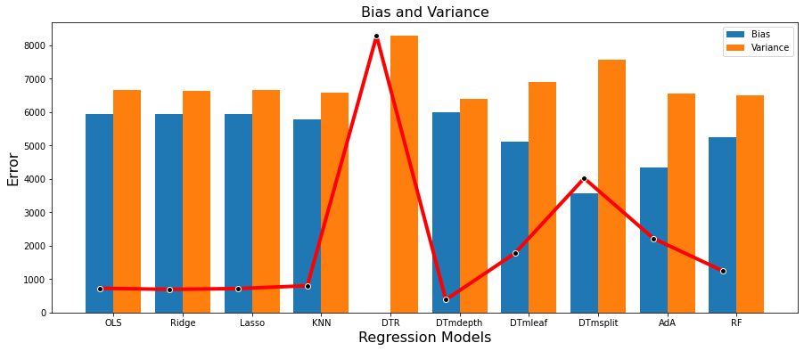

```python
w=0.4
name=list(Reg_Res["Model"])
Biases=list(Reg_Res["Bias"])
Variances=list(Reg_Res["Variance"])

bar1=np.arange(len(name))
bar2=[i+w for i in bar1]
plt.figure(figsize=(15,6))
plt.bar(bar1,Biases,w,label="Bias")
plt.bar(bar2,Variances,w,label="Variance")
plt.xlabel("Regression Models",size=16)
plt.ylabel("Error",size=16)
plt.title("Bias and Variance",size=16)
plt.xticks(bar1+(w/2),name)
plt.plot(Reg_Res["Difference"],color="red",lw="4",marker="o",mec="w",mfc="k")
plt.legend();
```

```python
Reg_Res
```

|  | Model | Bias | Variance | Difference |
| --- | --- | --- | --- | --- |
| 0 | OLS | 5929.095566 | 6654.721352 | 725.625787 |
| 1 | Ridge | 5929.454367 | 6621.457055 | 692.002688 |
| 2 | Lasso | 5928.651725 | 6644.884822 | 716.233096 |
| 3 | KNN | 5774.082893 | 6576.171634 | 802.088741 |
| 4 | DTR | 0.000000 | 8277.834532 | 8277.834532 |
| 5 | DTmdepth | 5995.439723 | 6377.718400 | 382.278677 |
| 6 | DTmleaf | 5113.334342 | 6886.257753 | 1772.923411 |
| 7 | DTmsplit | 3553.084564 | 7569.775741 | 4016.691177 |
| 8 | AdA | 4337.611276 | 6554.223362 | 2216.612086 |
| 9 | RF | 5247.363756 | 6494.403578 | 1247.039823 |

OLS Regression (adj Rsquared = 0.75581)

Training Error = 5929.0956

Testing Error = 6654.7214

Ridge Regression (alpha = 1.05)

Training Error = 5929.4544

Testing Error = 6621.4571

Lasso Regression (alpha = 0.95)

Training Error = 5928.6517

Testing Error = 6644.8848

KNN (neighbors = 14)

Training Error = 5774.0829

Testing Error = 6576.1716

Decision Tree Regressor

Training Error = 0.0

Testing Error = 8277.8345

Decision Tree Regressor (max_depth = 1)

Training Error = 5995.4397

Testing Error = 6377.7184

Decision Tree Regressor (min_samples_leaf = 19)

Training Error = 5113.3343

Testing Error = 6886.2578

Decision Tree Regressor (min_samples_split = 19)

Training Error = 3553.0846

Testing Error = 7569.7757

Decision Tree AdaBoost (n_estimators = 48)

Training Error = 4337.6113

Testing Error = 6554.2234

Random Forest (min_samples_leaf = 17, n_estimators = 13)

Training Error = 5247.3638

Testing Error = 6494.4036

# **Conclusion from Regression Models:**

### **The best model is *Decision Tree Max_Depth* with maximum depth value = 1**

### **Using Decision Tree (max_depth = 1) the difference between Training and Testing Error is equal to 382.278677**

# **Classification**

```python
a.head(3)
```

|  | Attrition | Age | DailyRate | DistanceFromHome | Education | EmployeeCount | EmployeeNumber | EnvironmentSatisfaction | HourlyRate | JobInvolvement | JobLevel | JobSatisfaction | MonthlyIncome | MonthlyRate | NumCompaniesWorked | PercentSalaryHike | PerformanceRating | RelationshipSatisfaction | StandardHours | StockOptionLevel | TotalWorkingYears | TrainingTimesLastYear | WorkLifeBalance | YearsAtCompany | YearsInCurrentRole | YearsSinceLastPromotion | YearsWithCurrManager | BusinessTravel | Department | … |
| --- | --- | --- | --- | --- | --- | --- | --- | --- | --- | --- | --- | --- | --- | --- | --- | --- | --- | --- | --- | --- | --- | --- | --- | --- | --- | --- | --- | --- | --- | --- |
| 0 | 1.0 | 41.0 | 1102.0 | 1.0 | 2.0 | 1.0 | 1.0 | 2.0 | 94.0 | 3.0 | 2.0 | 4.0 | 5993.0 | 19479.0 | 8.0 | 11.0 | 3.0 | 1.0 | 80.0 | 0.0 | 8.0 | 0.0 | 1.0 | 6.0 | 4.0 | 0.0 | 5.0 | Travel_Rarely | Sales | … |
| 1 | 0.0 | 49.0 | 279.0 | 8.0 | 1.0 | 1.0 | 2.0 | 3.0 | 61.0 | 2.0 | 2.0 | 2.0 | 5130.0 | 24907.0 | 1.0 | 23.0 | 4.0 | 4.0 | 80.0 | 1.0 | 10.0 | 3.0 | 3.0 | 10.0 | 7.0 | 1.0 | 7.0 | Travel_Frequently | Research & Development | … |
| 2 | 1.0 | 37.0 | 1373.0 | 2.0 | 2.0 | 1.0 | 4.0 | 4.0 | 92.0 | 2.0 | 1.0 | 3.0 | 2090.0 | 2396.0 | 6.0 | 15.0 | 3.0 | 2.0 | 80.0 | 0.0 | 7.0 | 3.0 | 3.0 | 0.0 | 0.0 | 0.0 | 0.0 | Travel_Rarely | Research & Development | … |

```python
cat,con=pf.catcon(a)
```

```python
a["Attrition"]=a["Attrition"].astype(str)
```

```python
imp_con=pf.ANOVA_cat(a,"Attrition")
```

```python
imp_con
```

```
['Age',
 'DailyRate',
 'DistanceFromHome',
 'EnvironmentSatisfaction',
 'JobInvolvement',
 'JobLevel',
 'JobSatisfaction',
 'MonthlyIncome',
 'StandardHours',
 'StockOptionLevel',
 'TotalWorkingYears',
 'TrainingTimesLastYear',
 'WorkLifeBalance',
 'YearsAtCompany',
 'YearsInCurrentRole',
 'YearsWithCurrManager']
```

```python
imp_cat=pf.CHI(a,"Attrition")
```

```python
imp_cat
```

```
[]
```

# **Defining X and Y**

```python
Ycat=a[["Attrition"]]
```

```python
Xcat=a[imp_con + cat]
```

```python
Xcat.head(3)
```

|  | Age | DailyRate | DistanceFromHome | EnvironmentSatisfaction | JobInvolvement | JobLevel | JobSatisfaction | MonthlyIncome | StandardHours | StockOptionLevel | TotalWorkingYears | TrainingTimesLastYear | WorkLifeBalance | YearsAtCompany | YearsInCurrentRole | YearsWithCurrManager | BusinessTravel | Department | EducationField | Gender | JobRole | MaritalStatus | Over18 | OverTime |
| --- | --- | --- | --- | --- | --- | --- | --- | --- | --- | --- | --- | --- | --- | --- | --- | --- | --- | --- | --- | --- | --- | --- | --- | --- |
| 0 | 41.0 | 1102.0 | 1.0 | 2.0 | 3.0 | 2.0 | 4.0 | 5993.0 | 80.0 | 0.0 | 8.0 | 0.0 | 1.0 | 6.0 | 4.0 | 5.0 | Travel_Rarely | Sales | Life Sciences | Female | Sales Executive | Single | Y | Yes |
| 1 | 49.0 | 279.0 | 8.0 | 3.0 | 2.0 | 2.0 | 2.0 | 5130.0 | 80.0 | 1.0 | 10.0 | 3.0 | 3.0 | 10.0 | 7.0 | 7.0 | Travel_Frequently | Research & Development | Life Sciences | Male | Research Scientist | Married | Y | No |
| 2 | 37.0 | 1373.0 | 2.0 | 4.0 | 2.0 | 1.0 | 3.0 | 2090.0 | 80.0 | 0.0 | 7.0 | 3.0 | 3.0 | 0.0 | 0.0 | 0.0 | Travel_Rarely | Research & Development | Other | Male | Laboratory Technician | Single | Y | Yes |

# **Preprocessing**

```python
Xcat_new=pf.prep(Xcat)
```

# **Model Creation**

```python
from sklearn.model_selection import train_test_split
xtrain,xtest,ytrain,ytest=train_test_split(Xcat_new,Ycat,test_size=0.2,random_state=31)
```

## **Logistic Regression Model**

```python
from sklearn.linear_model import LogisticRegression
lr=LogisticRegression()
model_lr=lr.fit(xtrain,ytrain)

pred_tr=model_lr.predict(xtrain)
pred_ts=model_lr.predict(xtest)

from sklearn.metrics import accuracy_score
tr_acc_lr = accuracy_score(ytrain,pred_tr)
ts_acc_lr = accuracy_score(ytest,pred_ts)
print("____________________________________________________________")
print("Training Accuracy Logistic Regression: ",tr_acc_lr)
print("Testing Accuracy Logistic Regression: ",ts_acc_lr)
print("____________________________________________________________")
#Confusion Matrix
print("_____________________Confusion Matrix_______________________","\n")
from sklearn.metrics import confusion_matrix
confusion_matrix(ytest,pred_ts)
```

```
____________________________________________________________
Training Accuracy Logistic Regression:  0.8557258791704238
Testing Accuracy Logistic Regression:  0.8561151079136691
____________________________________________________________
_____________________Confusion Matrix_______________________
```

```
array([[229,   3],
       [ 37,   9]])
```

```python
#Recall Score
from sklearn.preprocessing import LabelEncoder
le = LabelEncoder()
ytest1=le.fit_transform(ytest)
pred_ts1=le.fit_transform(pred_ts)
from sklearn.metrics import recall_score
recall_score(ytest1,pred_ts1)
```

```
0.1956521739130435
```

## **KNN Classifier**

```python
from sklearn.neighbors import KNeighborsClassifier
knc=KNeighborsClassifier(n_neighbors=5)
model_knc=knc.fit(xtrain,ytrain)
KNCbias=model_knc.predict(xtrain)
KNCvariance=model_knc.predict(xtest)

from sklearn.metrics import accuracy_score
tr_acc_KNN = accuracy_score(ytrain,KNCbias)
ts_acc_KNN = accuracy_score(ytest,KNCvariance)
print("____________________________________________________________")
print("Training Accuracy KNN: ",tr_acc_KNN)
print("Testing Accuracy KNN: ",ts_acc_KNN)
print("____________________________________________________________")
```

```
____________________________________________________________
Training Accuracy KNN:  0.8557258791704238
Testing Accuracy KNN:  0.8273381294964028
____________________________________________________________
```

### **Finding Value of n_neighbor**

```python
from sklearn.model_selection import GridSearchCV
tg={"n_neighbors":range(2,15)}
knc=KNeighborsClassifier()
cv=GridSearchCV(knc,tg,scoring="accuracy",cv=4)
cvmodel=cv.fit(Xcat_new,Ycat)
cvmodel.best_params_
```

```
{'n_neighbors': 6}
```

```python
from sklearn.neighbors import KNeighborsClassifier
knc=KNeighborsClassifier(n_neighbors=6)
model_knc=knc.fit(xtrain,ytrain)
KNCbias=model_knc.predict(xtrain)
KNCvariance=model_knc.predict(xtest)

from sklearn.metrics import accuracy_score
tr_acc_KNN = accuracy_score(ytrain,KNCbias)
ts_acc_KNN = accuracy_score(ytest,KNCvariance)
print("____________________________________________________________")
print("Training Accuracy KNN: ",tr_acc_KNN)
print("Testing Accuracy KNN: ",ts_acc_KNN)
print("____________________________________________________________")
```

```
____________________________________________________________
Training Accuracy KNN:  0.8494138863841298
Testing Accuracy KNN:  0.8381294964028777
____________________________________________________________
```

## **Decision Tree Classifier**

```python
from sklearn.tree import DecisionTreeClassifier
dtc=DecisionTreeClassifier(random_state=21)
model_dtc=dtc.fit(xtrain,ytrain)

pred_tr_DT=model_dtc.predict(xtrain)
pred_ts_DT=model_dtc.predict(xtest)

from sklearn.metrics import accuracy_score
acc_tr_DT = accuracy_score(ytrain,pred_tr_DT)
acc_ts_DT = accuracy_score(ytest,pred_ts_DT)

print("Training Accuracy: ",round(acc_tr_DT,4))
print("Testing Accuracy: ",round(acc_ts_DT,4))
```

```
Training Accuracy:  1.0
Testing Accuracy:  0.7266
```

## **Reduce overfitting by:**

**PRUNING**

1. max_depth
2. min_samples_leaf
3. min_samples_split

```python
from sklearn.model_selection import GridSearchCV

tg = {"max_depth":range(1,20)}
dtc = DecisionTreeClassifier(random_state=21,max_depth=3)

cv = GridSearchCV(dtc,tg,scoring="accuracy",cv=4)
cvmodel = cv.fit(xtrain,ytrain)
cvmodel.best_params_
```

```
{'max_depth': 2}
```

```python
from sklearn.model_selection import GridSearchCV

tg = {"min_samples_leaf":range(1,20)}
dtc = DecisionTreeClassifier(random_state=21,min_samples_leaf=10)

cv = GridSearchCV(dtc,tg,scoring="accuracy",cv=4)
cvmodel = cv.fit(xtrain,ytrain)
cvmodel.best_params_
```

```
{'min_samples_leaf': 13}
```

```python
from sklearn.model_selection import GridSearchCV

tg = {"min_samples_split":range(1,20)}
dtc = DecisionTreeClassifier(random_state=21,min_samples_split=10)

cv = GridSearchCV(dtc,tg,scoring="accuracy",cv=4)
cvmodel = cv.fit(xtrain,ytrain)
cvmodel.best_params_
```

```
{'min_samples_split': 18}
```

```python
from sklearn.tree import DecisionTreeClassifier
dtc=DecisionTreeClassifier(random_state=21,max_depth=2)
model_mdepthC=dtc.fit(xtrain,ytrain)

pred_tr_DT_max_depth=model_mdepthC.predict(xtrain)
pred_ts_DT_max_depth=model_mdepthC.predict(xtest)

from sklearn.metrics import accuracy_score
acc_tr_DT_max_depth = accuracy_score(ytrain,pred_tr_DT_max_depth)
acc_ts_DT_max_depth = accuracy_score(ytest,pred_ts_DT_max_depth)
print("___________________________________________")
print("Training Accuracy DTC max_depth: ",round(acc_tr_DT_max_depth,4))
print("Testing Accuracy DTC max_depth: ",round(acc_ts_DT_max_depth,4))
print("___________________________________________")
```

```
___________________________________________
Training Accuracy DTC max_depth:  0.8458
Testing Accuracy DTC max_depth:  0.8309
___________________________________________
```

```python
from sklearn.tree import DecisionTreeClassifier
dtc=DecisionTreeClassifier(random_state=21,min_samples_leaf=13)
model_mleafC=dtc.fit(xtrain,ytrain)

pred_tr_DT_mleaf=model_mleafC.predict(xtrain)
pred_ts_DT_mleaf=model_mleafC.predict(xtest)

from sklearn.metrics import accuracy_score
acc_tr_DT_mleaf = accuracy_score(ytrain,pred_tr_DT_mleaf)
acc_ts_DT_mleaf = accuracy_score(ytest,pred_ts_DT_mleaf)

print("___________________________________________")
print("Training Accuracy DTC min_samples_leaf: ",round(acc_tr_DT_mleaf,4))
print("Testing Accuracy DTC min_samples_leaf: ",round(acc_ts_DT_mleaf,4))
print("___________________________________________")
```

```
___________________________________________
Training Accuracy DTC min_samples_leaf:  0.8638
Testing Accuracy DTC min_samples_leaf:  0.8201
___________________________________________
```

```python
from sklearn.tree import DecisionTreeClassifier
dtc=DecisionTreeClassifier(random_state=21,min_samples_split=18)
model_msplitC=dtc.fit(xtrain,ytrain)

pred_tr_DT_msplit=model_msplitC.predict(xtrain)
pred_ts_DT_msplit=model_msplitC.predict(xtest)

from sklearn.metrics import accuracy_score
acc_tr_DT_msplit = accuracy_score(ytrain,pred_tr_DT_msplit)
acc_ts_DT_msplit = accuracy_score(ytest,pred_ts_DT_msplit)

print("___________________________________________")
print("Training Accuracy DTC min_samples_split: ",round(acc_tr_DT_msplit,4))
print("Testing Accuracy DTC min_samples_split: ",round(acc_ts_DT_msplit,4))
print("___________________________________________")
```

```
___________________________________________
Training Accuracy DTC min_samples_split:  0.9152
Testing Accuracy DTC min_samples_split:  0.7554
___________________________________________
```

## **Random Forest Classifier**

```python
from sklearn.ensemble import RandomForestClassifier
rfc = RandomForestClassifier(random_state=21,min_samples_leaf=13,n_estimators=30)
model_rfc = rfc.fit(xtrain,ytrain)
pred_tr_rf = model_rfc.predict(xtrain)
pred_ts_rf = model_rfc.predict(xtest)
from sklearn.metrics import accuracy_score
tr_acc_rf = accuracy_score(ytrain,pred_tr_rf)
ts_acc_rf = accuracy_score(ytest,pred_ts_rf)

print("___________________________________________")
print("Training Accuracy Random Forest: ",round(tr_acc_rf,4))
print("Testing Accuracy Random Forest: ",round(ts_acc_rf,4))
print("___________________________________________")
```

```
___________________________________________
Training Accuracy Random Forest:  0.8467
Testing Accuracy Random Forest:  0.8453
___________________________________________
```

### **Finding best parameters**

```python
tg = {"min_samples_leaf":range(2,20),"n_estimators":range(2,50)}

from sklearn.ensemble import RandomForestClassifier
rfc = RandomForestClassifier(random_state=21)

from sklearn.model_selection import GridSearchCV
cv = GridSearchCV(rfc,tg,scoring="accuracy",cv=4)

cvmodel = cv.fit(xtrain,ytrain)
cvmodel.best_params_
```

```
{'min_samples_leaf': 2, 'n_estimators': 25}
```

```python
from sklearn.ensemble import RandomForestClassifier
rfc = RandomForestClassifier(random_state=21,min_samples_leaf=2,n_estimators=25)
model_rfc = rfc.fit(xtrain,ytrain)
pred_tr_rf = model_rfc.predict(xtrain)
pred_ts_rf = model_rfc.predict(xtest)
from sklearn.metrics import accuracy_score
tr_acc_rf = accuracy_score(ytrain,pred_tr_rf)
ts_acc_rf = accuracy_score(ytest,pred_ts_rf)

print("___________________________________________")
print("Training Accuracy Random Forest: ",round(tr_acc_rf,4))
print("Testing Accuracy Random Forest: ",round(ts_acc_rf,4))
print("___________________________________________")
```

```
___________________________________________
Training Accuracy Random Forest:  0.9405
Testing Accuracy Random Forest:  0.8597
___________________________________________
```

## **AdaBoost**

```python
from sklearn.ensemble import AdaBoostClassifier
dtc = DecisionTreeClassifier(random_state=21,max_depth=2)
abc = AdaBoostClassifier(dtc,n_estimators=30)

model_abc=abc.fit(xtrain,ytrain)
pred_tr_ada=model_abc.predict(xtrain)
pred_ts_ada=model_abc.predict(xtest)

from sklearn.metrics import accuracy_score
acc_tr_ada = accuracy_score(ytrain,pred_tr_ada)
acc_ts_ada = accuracy_score(ytest,pred_ts_ada)
print("_____________________________________________")
print("Training Accuracy AdaBoost: ",round(acc_tr_ada,4))
print("Testing Accuracy AdaBoost: ",round(acc_ts_ada,4))
print("_____________________________________________")
```

```
_____________________________________________
Training Accuracy AdaBoost:  0.9008
Testing Accuracy AdaBoost:  0.7914
_____________________________________________
```

### **Finding Best Parameter**

```python
tg = {"n_estimators":range(2,50)}

from sklearn.ensemble import AdaBoostClassifier
abc = AdaBoostClassifier(dtc,n_estimators=30)

from sklearn.model_selection import GridSearchCV
cv = GridSearchCV(abc,tg,scoring="accuracy",cv=4)

cvmodel = cv.fit(xtrain,ytrain)
cvmodel.best_params_
```

```
{'n_estimators': 2}
```

```python
from sklearn.ensemble import AdaBoostClassifier
dtc = DecisionTreeClassifier(random_state=21,max_depth=2)
abc = AdaBoostClassifier(dtc,n_estimators=2)

model_abc=abc.fit(xtrain,ytrain)
pred_tr_ada=model_abc.predict(xtrain)
pred_ts_ada=model_abc.predict(xtest)

from sklearn.metrics import accuracy_score
acc_tr_ada = accuracy_score(ytrain,pred_tr_ada)
acc_ts_ada = accuracy_score(ytest,pred_ts_ada)
print("_____________________________________________")
print("Training Accuracy AdaBoost: ",round(acc_tr_ada,4))
print("Testing Accuracy AdaBoost: ",round(acc_ts_ada,4))
print("_____________________________________________")
```

```
_____________________________________________
Training Accuracy AdaBoost:  0.8341
Testing Accuracy AdaBoost:  0.8309
_____________________________________________
```

# **Classification Results**

```python
Class_Res=pd.DataFrame()

Class_Res["Model"]=["Logistic","KNN_C","DTC","DTmdepth","DTmleaf","DTmsplit","AdA","RF"]

Class_Res["Bias"]=[tr_acc_lr,tr_acc_KNN,acc_tr_DT,acc_tr_DT_max_depth,acc_tr_DT_mleaf,acc_tr_DT_msplit,acc_tr_ada,tr_acc_rf]

Class_Res["Variance"]=[ts_acc_lr,ts_acc_KNN,acc_ts_DT,acc_ts_DT_max_depth,acc_ts_DT_mleaf,acc_ts_DT_msplit,acc_ts_ada,ts_acc_rf]

Class_Res["Difference"]=Class_Res["Bias"]-Class_Res["Variance"]
```

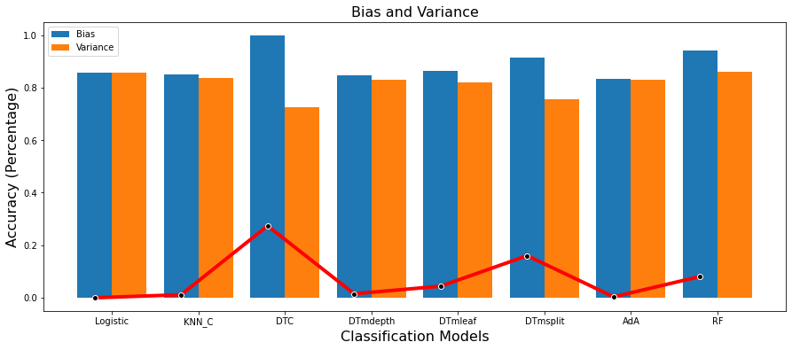

```python
w=0.4
name_c=list(Class_Res["Model"])
Biases_c=list(Class_Res["Bias"])
Variances_c=list(Class_Res["Variance"])

bar1=np.arange(len(name_c))
bar2=[i+w for i in bar1]
plt.figure(figsize=(15,6))
plt.bar(bar1,Biases_c,w,label="Bias")
plt.bar(bar2,Variances_c,w,label="Variance")
plt.xlabel("Classification Models",size=16)
plt.ylabel("Accuracy (Percentage)",size=16)
plt.title("Bias and Variance",size=16)
plt.xticks(bar1+(w/2),name_c)
plt.plot(Class_Res["Difference"],color="red",lw="4",marker="o",mec="w",mfc="k")
plt.legend();
```

```python
Class_Res
```

|  | Model | Bias | Variance | Difference |
| --- | --- | --- | --- | --- |
| 0 | Logistic | 0.855726 | 0.856115 | -0.000389 |
| 1 | KNN_C | 0.849414 | 0.838129 | 0.011284 |
| 2 | DTC | 1.000000 | 0.726619 | 0.273381 |
| 3 | DTmdepth | 0.845807 | 0.830935 | 0.014872 |
| 4 | DTmleaf | 0.863841 | 0.820144 | 0.043697 |
| 5 | DTmsplit | 0.915239 | 0.755396 | 0.159843 |
| 6 | AdA | 0.834085 | 0.830935 | 0.003150 |
| 7 | RF | 0.940487 | 0.859712 | 0.080775 |

Logistic Regression (recall score = 0.1956)

Training Accuracy = 0.8557

Testing Accuracy = 0.8561

KNN (neighbors = 6)

Training Accuracy = 0.8494

Testing Accuracy = 0.8381

Decision Tree Classifier

Training Accuracy = 1.0

Testing Accuracy = 0.726

Decision Tree Classifier (max_depth = 2)

Training Accuracy = 0.8458

Decision Tree Classifier (min_samples_leaf = 13)

Training Accuracy = 0.8638

Testing Accuracy = 0.8201

Decision Tree Classifier (min_samples_split = 18)

Training Accuracy = 0.9152

Testing Accuracy = 0.7554

Decision Tree AdaBoost (n_estimators = 2)

Training Accuracy = 0.8341

Testing Accuracy = 0.8309

Random Forest (min_samples_leaf = 2, n_estimators = 25)

Training Accuracy = 0.9405

Testing Accuracy = 0.8597

# **Conclusion from Classification Models:**

### **The best models are *AdaBoost Model (with n_estimators = 2) and LogisticRegression Model***